# Merging, Modeling and Clustering

Fundamental Techniques in Data Science with R

## Today

## This lecture and practical

- Merging Data / Data Table
- Linear models
- Robust linear modeling
- Logistic models
- Visualizing marginal effects
- Clustering

## Packages used

```r
library(dplyr)
library(magrittr)
library(mice)
library(bench)
library(ggplot2)
library(class)
library(mvtnorm)
library(psych)
library(caret)
```

## Joining data in base `R`

## Merging data sets

Let’s consider the following data example:

```r
df1 <- data.frame(id = c(1:6),
                  city = c(rep("Utrecht", 3), rep("Rotterdam", 3)))
df2 <- data.frame(ID = c(2, 4, 6),
                  year = c(1984, 1982, 1990))
head(df1)
```

```
##   id      city
## 1  1   Utrecht
## 2  2   Utrecht
## 3  3   Utrecht
## 4  4 Rotterdam
## 5  5 Rotterdam
## 6  6 Rotterdam
```

```r
head(df2)
```

```
##   ID year
## 1  2 1984
## 2  4 1982
## 3  6 1990
```

## Inner join

```r
merge(x = df1, y = df2, by.x = "id", by.y = "ID")
```

```
##   id      city year
## 1  2   Utrecht 1984
## 2  4 Rotterdam 1982
## 3  6 Rotterdam 1990
```

This is a **natural join**, or **inner join**. Only the cases from `df1` that have a match in `df2` are returned.

## Outer join

```r
merge(x = df1, y = df2, by.x = "id", by.y = "ID", all = TRUE)
```

```
##   id      city year
## 1  1   Utrecht   NA
## 2  2   Utrecht 1984
## 3  3   Utrecht   NA
## 4  4 Rotterdam 1982
## 5  5 Rotterdam   NA
## 6  6 Rotterdam 1990
```

All rows are returned

## Outer join TOWA

```r
merge(y = df1, x = df2, by.y = "id", by.x = "ID", all = TRUE)
```

```
##   ID year      city
## 1  1   NA   Utrecht
## 2  2 1984   Utrecht
## 3  3   NA   Utrecht
## 4  4 1982 Rotterdam
## 5  5   NA Rotterdam
## 6  6 1990 Rotterdam
```

## Left outer join

```r
merge(x = df1, y = df2, by.x = "id", by.y = "ID", all.x = TRUE)
```

```
##   id      city year
## 1  1   Utrecht   NA
## 2  2   Utrecht 1984
## 3  3   Utrecht   NA
## 4  4 Rotterdam 1982
## 5  5 Rotterdam   NA
## 6  6 Rotterdam 1990
```

## Left outer join TOWA

```r
merge(y = df1, x = df2, by.y = "id", by.x = "ID", all.x = TRUE)
```

```
##   ID year      city
## 1  2 1984   Utrecht
## 2  4 1982 Rotterdam
## 3  6 1990 Rotterdam
```

## Right outer join

```r
merge(x = df1, y = df2, by.x = "id", by.y = "ID", all.y = TRUE)
```

```
##   id      city year
## 1  2   Utrecht 1984
## 2  4 Rotterdam 1982
## 3  6 Rotterdam 1990
```

## joining data with `dplyr`

## Data sets

```r
band_members
```

```
## # A tibble: 3 x 2
##   name  band
##   <chr> <chr>
## 1 Mick  Stones
## 2 John  Beatles
## 3 Paul  Beatles
```

```r
band_instruments
```

```
## # A tibble: 3 x 2
##   name  plays
##   <chr> <chr>
## 1 John  guitar
## 2 Paul  bass
## 3 Keith guitar
```

## inner join

```r
band_members %>% inner_join(band_instruments)
```

```
## # A tibble: 2 x 3
##   name  band    plays
##   <chr> <chr>   <chr>
## 1 John  Beatles guitar
## 2 Paul  Beatles bass
```

`dplyr::inner_join(x, y)` returns all rows from x where there are matching values in `y`, and all columns from `x` and `y`.

- If there are multiple matches between `x` and `y`, all combination of the matches are returned.

## left join

```r
band_members %>% left_join(band_instruments)
```

```
## # A tibble: 3 x 3
##   name  band    plays
##   <chr> <chr>   <chr>
## 1 Mick  Stones  <NA>
## 2 John  Beatles guitar
## 3 Paul  Beatles bass
```

`dplyr::left_join(x, y)` returns all rows from `x`, and all columns from `x` and `y`.

- Rows in `x` with no match in `y` will have `NA` values in the new columns.
- If there are multiple matches between `x` and `y`, all combinations of the matches are returned.

## right join

```r
band_members %>% right_join(band_instruments)
```

```
## # A tibble: 3 x 3
##   name  band    plays
##   <chr> <chr>   <chr>
## 1 John  Beatles guitar
## 2 Paul  Beatles bass
## 3 Keith <NA>    guitar
```

`dplyr::right_join(x, y)` returns all rows from `y`, and all columns from `x` and `y`.

- Rows in `y` with no match in `x` will have `NA` values in the new columns.
- If there are multiple matches between `x` and `y`, all combinations of the matches are returned.

## full join

```r
band_members %>% full_join(band_instruments)
```

```
## # A tibble: 4 x 3
##   name  band    plays
##   <chr> <chr>   <chr>
## 1 Mick  Stones  <NA>
## 2 John  Beatles guitar
## 3 Paul  Beatles bass
## 4 Keith <NA>    guitar
```

`dplyr::full_join(x, y)` returns all rows and all columns from both x and y. Where there are not matching values, returns NA for the one missing.

## Filtering joins: semi

- `dplyr::semi_join(x, y)`

```r
band_members %>% semi_join(band_instruments, by = "name")
```

```
## # A tibble: 2 x 2
##   name  band
##   <chr> <chr>
## 1 John  Beatles
## 2 Paul  Beatles
```

- `dplyr::anti_join(x, y)`

```r
band_members %>% anti_join(band_instruments, by = "name")
```

```
## # A tibble: 1 x 2
##   name  band
##   <chr> <chr>
## 1 Mick  Stones
```

## nest join

```r
band_members %>% nest_join(band_instruments, by = "name")
```

```
## # A tibble: 3 x 3
##   name  band    band_instruments
## * <chr> <chr>   <list>
## 1 Mick  Stones  <tibble [0 × 1]>
## 2 John  Beatles <tibble [1 × 1]>
## 3 Paul  Beatles <tibble [1 × 1]>
```

## Tibbles

```r
a <- band_members %>% nest_join(band_instruments)
a$band_instruments
```

```
## [[1]]
## # A tibble: 0 x 1
## # … with 1 variable: plays <chr>
##
## [[2]]
## # A tibble: 1 x 1
##   plays
##   <chr>
## 1 guitar
##
## [[3]]
## # A tibble: 1 x 1
##   plays
##   <chr>
## 1 bass
```

## Tibbles

```r
set.seed(123)
l <- replicate(26, sample(1000), simplify = FALSE)
names(l) <- letters

timing <- bench::mark(
  as_tibble(l),
  as.data.frame(l),
  check = FALSE)

timing
```

```
## # A tibble: 2 x 6
##   expression            min   median `itr/sec` mem_alloc `gc/sec`
##   <bch:expr>       <bch:tm> <bch:tm>     <dbl> <bch:byt>    <dbl>
## 1 as_tibble(l)        255µs    276µs     3546.   189.9KB     6.16
## 2 as.data.frame(l)    945µs      1ms      957.    4.91KB     6.19
```

## Naming with `tibble`

```r
a <- data.frame(abc = 1)
a$a
```

```
## [1] 1
```

```r
a <- tibble(abc = 1)
a$a
```

```r
a$abc
```

```
## [1] 1
```

## Linear models

## The linear model

## Notation

The mathematical formulation of the relationship between variables can be written as

\[ \mbox{observed}=\mbox{predicted}+\mbox{error} \]

or (for the greek people) in notation as \[y=\mu+\varepsilon\]

where

- \(\mu\) (mean) is the part of the outcome that is explained by model
- \(\varepsilon\) (residual) is the part of outcome that is not explained by model

## Univariate expectation

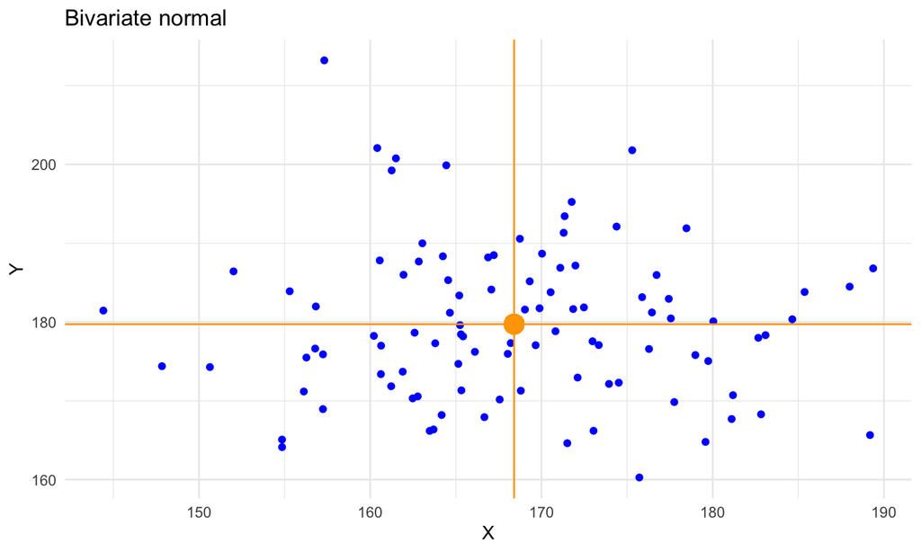

## Conditional expectation

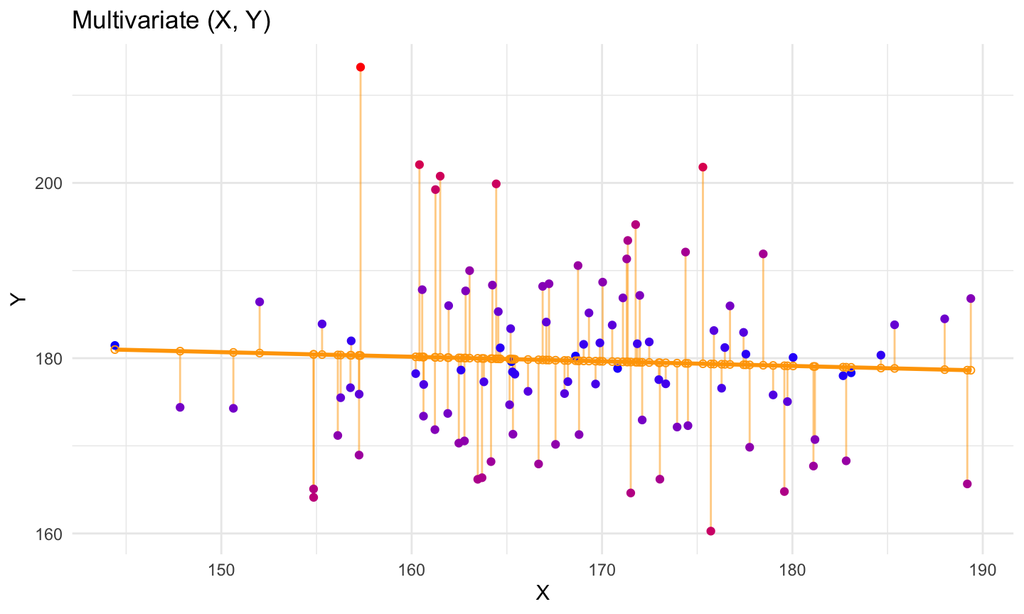

## Assumptions

## The key assumptions

There are four key assumptions about the use of linear regression models.

In short, we assume

- The outcome to have a **linear relation** with the predictors and the predictor relations to be **additive**.
  - the expected value for the outcome is a straight-line function of each predictor, given that the others are fixed.
  - the slope of each line does not depend on the values of the other predictors
  - the effects of the predictors on the expected value are additive

  \[ y = \alpha + \beta_1X_1 + \beta_2X_2 + \beta_3X_3 + \epsilon\]
- The residuals are statistically **independent**
- The residual **variance is constant**
  - accross the expected values
  - across any of the predictors
- The residuals are **normally distributed** with mean \(\mu_\epsilon = 0\)

## A simple model

```r
fit <- anscombe %$%
  lm(y1 ~ x1)
fit
```

```
##
## Call:
## lm(formula = y1 ~ x1)
##
## Coefficients:
## (Intercept)           x1
##      3.0001       0.5001
```

```r
fit2 <- anscombe %$%
  lm(y2 ~ x2)
```

## Visualizing the assumptions

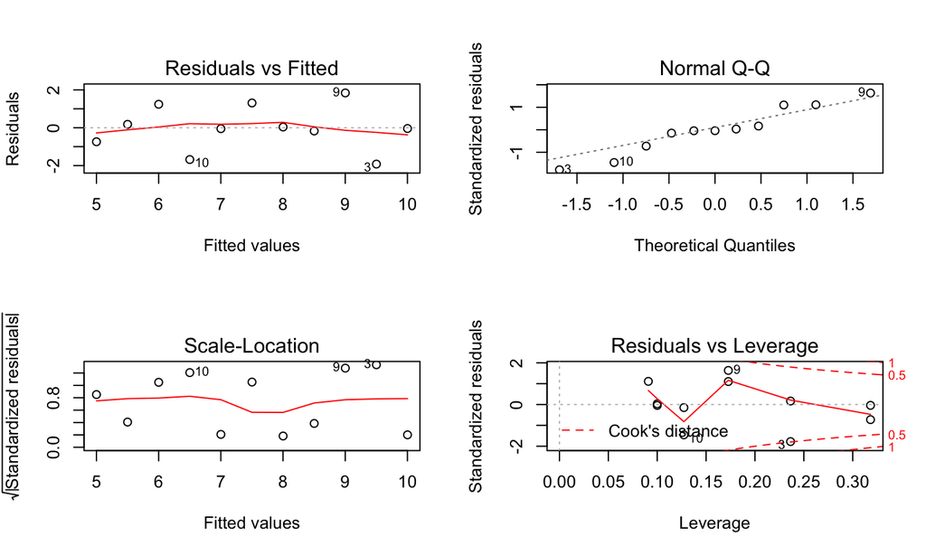

```r
par(mfrow = c(2, 2))
plot(fit)
```

## Visualizing the assumptions

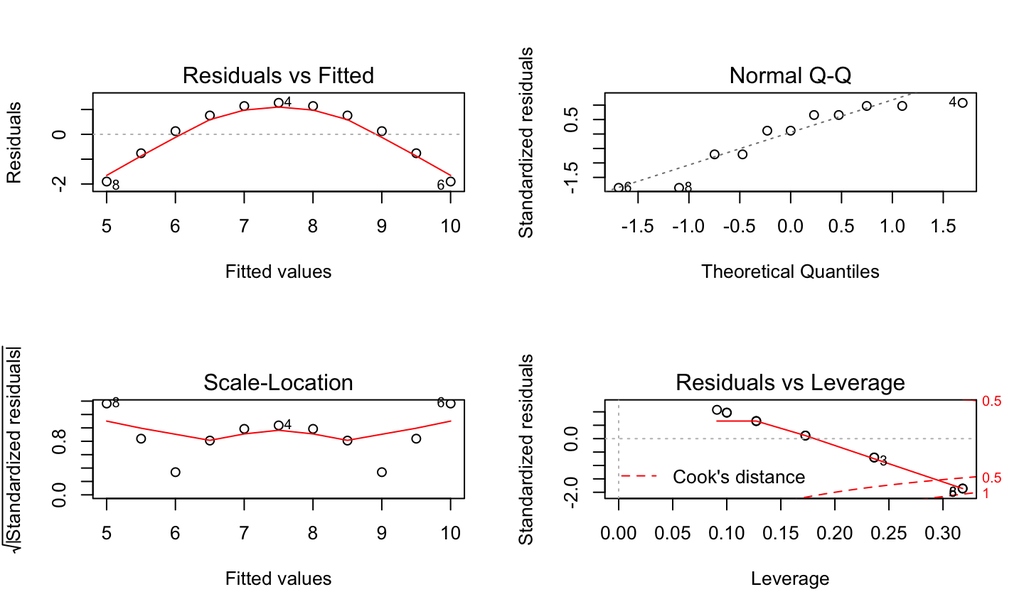

```r
par(mfrow = c(2, 2))
plot(fit2)
```

## Model fit

## A simple model

```r
boys.fit <-
  na.omit(boys) %$% # Extremely wasteful
  lm(age ~ reg)
boys.fit
```

```
##
## Call:
## lm(formula = age ~ reg)
##
## Coefficients:
## (Intercept)      regeast      regwest     regsouth      regcity
##     14.7109      -0.8168      -0.7044      -0.6913      -0.6663
```

```r
boys %>% na.omit(boys) %$% aggregate(age, list(reg), mean)
```

```
##   Group.1        x
## 1   north 14.71094
## 2    east 13.89410
## 3    west 14.00657
## 4   south 14.01965
## 5    city 14.04460
```

## Plotting the model

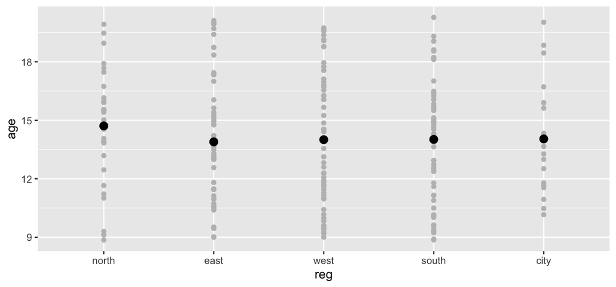

```r
means <- boys %>% na.omit(boys) %>% group_by(reg) %>% summarise(age = mean(age))
ggplot(na.omit(boys), aes(x = reg, y = age)) +
  geom_point(color = "grey") +
  geom_point(data = means, stat = "identity", size = 3)
```

## Model parameters

```r
boys.fit %>%
  summary()
```

```
##
## Call:
## lm(formula = age ~ reg)
##
## Residuals:
##     Min      1Q  Median      3Q     Max
## -5.8519 -2.5301  0.0254  2.2274  6.2614
##
## Coefficients:
##             Estimate Std. Error t value Pr(>|t|)
## (Intercept)  14.7109     0.5660  25.993   <2e-16 ***
## regeast      -0.8168     0.7150  -1.142    0.255
## regwest      -0.7044     0.6970  -1.011    0.313
## regsouth     -0.6913     0.6970  -0.992    0.322
## regcity      -0.6663     0.9038  -0.737    0.462
## ---
## Signif. codes:  0 '***' 0.001 '**' 0.01 '*' 0.05 '.' 0.1 ' ' 1
##
## Residual standard error: 3.151 on 218 degrees of freedom
## Multiple R-squared:  0.006745,   Adjusted R-squared:  -0.01148
## F-statistic: 0.3701 on 4 and 218 DF,  p-value: 0.8298
```

## Scientific notation

If you have trouble reading scientific notation, `2e-16` means the following

\[2\text{e-16} = 2 \times 10^{-16} = 2 \times (\frac{1}{10})^{-16}\]

This indicates that the comma should be moved 16 places to the left:

\[2\text{e-16} = 0.0000000000000002\]

## AIC

Akaike’s *An Information Criterion*

```r
boys.fit %>%
  AIC()
```

```
## [1] 1151.684
```

### What is AIC

AIC comes from information theory and can be used for model selection. The AIC quantifies the information that is lost by the statistical model, through the assumption that the data come from the same model. In other words: AIC measures the fit of the model to the data.

- The better the fit, the less the loss in information
- AIC works on the log scale:
  - \(\text{log}(0) = -\infty\), \(\text{log}(1) = 0\), etc.
- the closer the AIC is to \(-\infty\), the better

## Model comparison

## A new model

Let’s add predictor `hgt` to the model:

```r
boys.fit2 <-
  na.omit(boys) %$%
  lm(age ~ reg + hgt)

boys.fit %>% AIC()
```

```
## [1] 1151.684
```

```r
boys.fit2 %>% AIC()
```

```
## [1] 836.3545
```

## Another model

Let’s add `wgt` to the model

```r
boys.fit3 <-
  na.omit(boys) %$%
  lm(age ~ reg + hgt + wgt)
```

## And another model

Let’s add `wgt` and the interaction between `wgt` and `hgt` to the model

```r
boys.fit4 <-
  na.omit(boys) %$%
  lm(age ~ reg + hgt * wgt)
```

is equivalent to

```r
boys.fit4 <-
  na.omit(boys) %$%
  lm(age ~ reg + hgt + wgt + hgt:wgt)
```

## Model comparison

```r
AIC(boys.fit, boys.fit2, boys.fit3, boys.fit4)
```

```
##           df       AIC
## boys.fit   6 1151.6839
## boys.fit2  7  836.3545
## boys.fit3  8  822.4164
## boys.fit4  9  823.0386
```

## And with `anova()`

```r
anova(boys.fit, boys.fit2, boys.fit3, boys.fit4)
```

```
## Analysis of Variance Table
##
## Model 1: age ~ reg
## Model 2: age ~ reg + hgt
## Model 3: age ~ reg + hgt + wgt
## Model 4: age ~ reg + hgt * wgt
##   Res.Df     RSS Df Sum of Sq        F    Pr(>F)
## 1    218 2164.59
## 2    217  521.64  1   1642.94 731.8311 < 2.2e-16 ***
## 3    216  485.66  1     35.98  16.0276 8.595e-05 ***
## 4    215  482.67  1      2.99   1.3324    0.2497
## ---
## Signif. codes:  0 '***' 0.001 '**' 0.01 '*' 0.05 '.' 0.1 ' ' 1
```

## Inspect `boys.fit3`

```r
boys.fit3 %>% anova()
```

```
## Analysis of Variance Table
##
## Response: age
##            Df  Sum Sq Mean Sq  F value    Pr(>F)
## reg         4   14.70    3.67   1.6343    0.1667
## hgt         1 1642.94 1642.94 730.7065 < 2.2e-16 ***
## wgt         1   35.98   35.98  16.0029 8.688e-05 ***
## Residuals 216  485.66    2.25
## ---
## Signif. codes:  0 '***' 0.001 '**' 0.01 '*' 0.05 '.' 0.1 ' ' 1
```

## Inspect `boys.fit4`

```r
boys.fit4 %>% anova()
```

```
## Analysis of Variance Table
##
## Response: age
##            Df  Sum Sq Mean Sq  F value    Pr(>F)
## reg         4   14.70    3.67   1.6368    0.1661
## hgt         1 1642.94 1642.94 731.8311 < 2.2e-16 ***
## wgt         1   35.98   35.98  16.0276 8.595e-05 ***
## hgt:wgt     1    2.99    2.99   1.3324    0.2497
## Residuals 215  482.67    2.24
## ---
## Signif. codes:  0 '***' 0.001 '**' 0.01 '*' 0.05 '.' 0.1 ' ' 1
```

It seems that `reg` and the interaction `hgt:wgt` are redundant

## Remove `reg`

```r
boys.fit5 <-
  na.omit(boys) %$%
  lm(age ~ hgt + wgt)
```

Let’s revisit the comparison

```r
anova(boys.fit, boys.fit2, boys.fit3, boys.fit5)
```

```
## Analysis of Variance Table
##
## Model 1: age ~ reg
## Model 2: age ~ reg + hgt
## Model 3: age ~ reg + hgt + wgt
## Model 4: age ~ hgt + wgt
##   Res.Df     RSS Df Sum of Sq        F    Pr(>F)
## 1    218 2164.59
## 2    217  521.64  1   1642.94 730.7065 < 2.2e-16 ***
## 3    216  485.66  1     35.98  16.0029 8.688e-05 ***
## 4    220  492.43 -4     -6.77   0.7529    0.5571
## ---
## Signif. codes:  0 '***' 0.001 '**' 0.01 '*' 0.05 '.' 0.1 ' ' 1
```

The `boys.fit5` model is better than the previous model - it has fewer parameters

## Stepwise regression

We start with the full model, which contains all parameters for all columns.

The most straightforward way to go about this is by specifying the following model:

```r
full.model <- lm(age ~ ., data = na.omit(boys))
full.model
```

```
##
## Call:
## lm(formula = age ~ ., data = na.omit(boys))
##
## Coefficients:
## (Intercept)          hgt          wgt          bmi           hc
##    2.556051     0.059987    -0.009846     0.142162    -0.024086
##       gen.L        gen.Q        gen.C        gen^4        phb.L
##    1.287455    -0.006861    -0.187256     0.034186     1.552398
##       phb.Q        phb.C        phb^4        phb^5           tv
##    0.499620     0.656277    -0.094722    -0.113686     0.074321
##     regeast      regwest     regsouth      regcity
##   -0.222249    -0.233307    -0.258771     0.188423
```

## Stepwise regression - continued

We can then start with specifying the stepwise model. In this case we choose direction `both`.

```r
step.model <- step(full.model, direction = "both",
                      trace = FALSE)
step.model
```

```
##
## Call:
## lm(formula = age ~ hgt + bmi + phb + tv, data = na.omit(boys))
##
## Coefficients:
## (Intercept)          hgt          bmi        phb.L        phb.Q
##     2.07085      0.05482      0.10742      2.70328      0.28877
##       phb.C        phb^4        phb^5           tv
##     0.48492     -0.06225     -0.15167      0.07957
```

Other options are

- `forward`: fit all univariate models, add the best predictor and continue.
- `backward`: fit the full model, eliminate the worst predictor and continue.

## Summary

```r
step.model %>% summary
```

```
##
## Call:
## lm(formula = age ~ hgt + bmi + phb + tv, data = na.omit(boys))
##
## Residuals:
##     Min      1Q  Median      3Q     Max
## -3.5077 -0.7144 -0.0814  0.6850  3.1724
##
## Coefficients:
##              Estimate Std. Error t value Pr(>|t|)
## (Intercept)  2.070854   1.576365   1.314  0.19036
## hgt          0.054822   0.009986   5.490 1.13e-07 ***
## bmi          0.107415   0.030135   3.564  0.00045 ***
## phb.L        2.703275   0.437108   6.184 3.12e-09 ***
## phb.Q        0.288768   0.211836   1.363  0.17426
## phb.C        0.484921   0.202856   2.390  0.01769 *
## phb^4       -0.062246   0.208472  -0.299  0.76555
## phb^5       -0.151667   0.240599  -0.630  0.52912
## tv           0.079573   0.019600   4.060 6.89e-05 ***
## ---
## Signif. codes:  0 '***' 0.001 '**' 0.01 '*' 0.05 '.' 0.1 ' ' 1
##
## Residual standard error: 1.172 on 214 degrees of freedom
## Multiple R-squared:  0.8651, Adjusted R-squared:   0.86
## F-statistic: 171.5 on 8 and 214 DF,  p-value: < 2.2e-16
```

## Stepwise regression - AIC

```r
full.model <- lm(age ~ ., data = na.omit(boys))
step.model <- MASS::stepAIC(full.model, direction = "both",
                      trace = FALSE)
step.model
```

```
##
## Call:
## lm(formula = age ~ hgt + bmi + phb + tv, data = na.omit(boys))
##
## Coefficients:
## (Intercept)          hgt          bmi        phb.L        phb.Q
##     2.07085      0.05482      0.10742      2.70328      0.28877
##       phb.C        phb^4        phb^5           tv
##     0.48492     -0.06225     -0.15167      0.07957
```

## Influence of cases

DfBeta calculates the change in coefficients depicted as deviation in SE’s.

```r
step.model %>%
  dfbeta() %>%
  head(n = 7)
```

```
##       (Intercept)           hgt           bmi        phb.L         phb.Q
## 3279 -0.142127090  0.0010828575 -0.0021654085 -0.021523825 -0.0006087783
## 3283 -0.005201914  0.0001127452 -0.0014100750  0.009068652 -0.0147293625
## 3296 -0.081439010  0.0004244061  0.0002603379 -0.009247562 -0.0071293767
## 3321 -0.084630826  0.0004186923  0.0008222594 -0.005498486 -0.0059276580
## 3323  0.154386486 -0.0004476521 -0.0052964367  0.042872835 -0.0213761347
## 3327 -0.046095468  0.0001081361  0.0011150546 -0.004047875 -0.0085461280
## 3357 -0.045933397  0.0001345605  0.0009770371 -0.005087053 -0.0062604484
##            phb.C        phb^4        phb^5            tv
## 3279 0.007427067 -0.004226982 -0.001213833  0.0001061106
## 3283 0.011761595 -0.005498411  0.001164307  0.0007051901
## 3296 0.008538302 -0.003688611  0.000842872  0.0002494383
## 3321 0.006839217 -0.003341741  0.000866896 -0.0002569914
## 3323 0.011758694 -0.006659755  0.000493897  0.0012317886
## 3327 0.007807966 -0.002901270  0.001499505  0.0003376220
## 3357 0.006152384 -0.002274777  0.001148552  0.0002329346
```

## Prediction

## Fitted values

Let’s use the simpler `anscombe` data example

```r
fit <- anscombe %$% lm(y1 ~ x1)

y_hat <-
  fit %>%
  fitted.values()
```

```r
y_hat - anscombe$y1
```

```
##           1           2           3           4           5           6
## -0.03900000  0.05081818  1.92127273 -1.30909091  0.17109091  0.04136364
##           7           8           9          10          11
## -1.23936364  0.74045455 -1.83881818  1.68072727 -0.17945455
```

## Predict new values

If we introduce new values for the predictor `x1`, we can generate predicted values from the model

```r
new.x1 <- data.frame(x1 = 1:20)
fit %>% predict(newdata = new.x1)
```

```
##         1         2         3         4         5         6         7
##  3.500182  4.000273  4.500364  5.000455  5.500545  6.000636  6.500727
##         8         9        10        11        12        13        14
##  7.000818  7.500909  8.001000  8.501091  9.001182  9.501273 10.001364
##        15        16        17        18        19        20
## 10.501455 11.001545 11.501636 12.001727 12.501818 13.001909
```

## Prediction intervals

```r
fit %>% predict(interval = "prediction")
```

```
##          fit      lwr       upr
## 1   8.001000 5.067072 10.934928
## 2   7.000818 4.066890  9.934747
## 3   9.501273 6.390801 12.611745
## 4   7.500909 4.579129 10.422689
## 5   8.501091 5.531014 11.471168
## 6  10.001364 6.789620 13.213107
## 7   6.000636 2.971271  9.030002
## 8   5.000455 1.788711  8.212198
## 9   9.001182 5.971816 12.030547
## 10  6.500727 3.530650  9.470804
## 11  5.500545 2.390073  8.611017
```

A prediction interval reflects the uncertainty around a single value. The confidence interval reflects the uncertainty around the mean prediction values.

## Assessing predictive accuracy

## K-fold cross-validation

- Divide sample in \(k\) mutually exclusive training sets
- Do for all \(j\in\{1,\dots,k\}\) training sets
  1. fit model to training set \(j\)
  2. obtain predictions for test set \(j\) (remaining cases)
  3. compute residual variance (MSE) for test set \(j\)
- Compare MSE in cross-validation with MSE in sample
- Small difference suggests good predictive accuracy

## The original model

```r
fit %>% summary()
```

```
##
## Call:
## lm(formula = y1 ~ x1)
##
## Residuals:
##      Min       1Q   Median       3Q      Max
## -1.92127 -0.45577 -0.04136  0.70941  1.83882
##
## Coefficients:
##             Estimate Std. Error t value Pr(>|t|)
## (Intercept)   3.0001     1.1247   2.667  0.02573 *
## x1            0.5001     0.1179   4.241  0.00217 **
## ---
## Signif. codes:  0 '***' 0.001 '**' 0.01 '*' 0.05 '.' 0.1 ' ' 1
##
## Residual standard error: 1.237 on 9 degrees of freedom
## Multiple R-squared:  0.6665, Adjusted R-squared:  0.6295
## F-statistic: 17.99 on 1 and 9 DF,  p-value: 0.00217
```

## K-fold cross-validation `anscombe` data

```r
set.seed(123)
train.control <- trainControl(method = "cv", number = 3)
model <- train(y1 ~ x1, data = anscombe, method = "lm",
               trControl = train.control)
model
```

```
## Linear Regression
##
## 11 samples
##  1 predictor
##
## No pre-processing
## Resampling: Cross-Validated (3 fold)
## Summary of sample sizes: 7, 8, 7
## Resampling results:
##
##   RMSE      Rsquared   MAE
##   1.401633  0.7152385  1.152423
##
## Tuning parameter 'intercept' was held constant at a value of TRUE
```

## Another approach

```r
library(lmvar)
fit <- anscombe %$% lm(y1 ~ x1, y = TRUE, x = TRUE)
lmvar::cv.lm(fit, k = 3, seed = 123)
```

```
## Mean absolute error        :  1.188572
## Sample standard deviation  :  0.5803123
##
## Mean squared error         :  2.143293
## Sample standard deviation  :  1.37752
##
## Root mean squared error    :  1.402769
## Sample standard deviation  :  0.5131254
```

## K-fold cross-validation `boys` data

```r
set.seed(123)
train.control <- trainControl(method = "cv", number = 3)
model <- train(formula(step.model), data = na.omit(boys), method = "lm",
               trControl = train.control)
model
```

```
## Linear Regression
##
## 223 samples
##   4 predictor
##
## No pre-processing
## Resampling: Cross-Validated (3 fold)
## Summary of sample sizes: 150, 149, 147
## Resampling results:
##
##   RMSE      Rsquared   MAE
##   1.186488  0.8572233  0.9427666
##
## Tuning parameter 'intercept' was held constant at a value of TRUE
```

## Another approach

```r
fit <- anscombe %$% lm(y1 ~ x1, y = TRUE, x = TRUE)
lmvar::cv.lm(fit, k = 3)
```

```
## Mean absolute error        :  0.7748689
## Sample standard deviation  :  0.165071
##
## Mean squared error         :  1.13766
## Sample standard deviation  :  0.4766553
##
## Root mean squared error    :  1.051753
## Sample standard deviation  :  0.217285
```

## How many cases are used?

```r
na.omit(boys) %$%
  lm(age ~ reg + hgt * wgt) %>%
  nobs()
```

```
## [1] 223
```

If we would not have used `na.omit()`

```r
boys %$%
  lm(age ~ reg + hgt * wgt) %>%
  nobs()
```

```
## [1] 724
```

## Logistic models

## Example: titanic data

We use a data set that logs the survival of passengers on board of the disastrous maiden voyage of the ocean liner Titanic

```r
titanic <- read.csv(file = "titanic.csv", header = TRUE, )
titanic %>% describe
```

```
##                         vars   n   mean     sd median trimmed    mad  min
## Survived                   1 887   0.39   0.49   0.00    0.36   0.00 0.00
## Pclass                     2 887   2.31   0.84   3.00    2.38   0.00 1.00
## Name*                      3 887 444.00 256.20 444.00  444.00 329.14 1.00
## Sex*                       4 887   1.65   0.48   2.00    1.68   0.00 1.00
## Age                        5 887  29.47  14.12  28.00   28.96  11.86 0.42
## Siblings.Spouses.Aboard    6 887   0.53   1.10   0.00    0.27   0.00 0.00
## Parents.Children.Aboard    7 887   0.38   0.81   0.00    0.19   0.00 0.00
## Fare                       8 887  32.31  49.78  14.45   21.50  10.32 0.00
##                            max  range  skew kurtosis   se
## Survived                  1.00   1.00  0.47    -1.78 0.02
## Pclass                    3.00   2.00 -0.62    -1.29 0.03
## Name*                   887.00 886.00  0.00    -1.20 8.60
## Sex*                      2.00   1.00 -0.61    -1.63 0.02
## Age                      80.00  79.58  0.45     0.28 0.47
## Siblings.Spouses.Aboard   8.00   8.00  3.67    17.64 0.04
## Parents.Children.Aboard   6.00   6.00  2.73     9.63 0.03
## Fare                    512.33 512.33  4.76    32.99 1.67
```

## Inspect the data set

```r
str(titanic)
```

```
## 'data.frame':    887 obs. of  8 variables:
##  $ Survived               : int  0 1 1 1 0 0 0 0 1 1 ...
##  $ Pclass                 : int  3 1 3 1 3 3 1 3 3 2 ...
##  $ Name                   : Factor w/ 887 levels "Capt. Edward Gifford Crosby",..: 602 823 172 814 733 464 700 33 842 839 ...
##  $ Sex                    : Factor w/ 2 levels "female","male": 2 1 1 1 2 2 2 2 1 1 ...
##  $ Age                    : num  22 38 26 35 35 27 54 2 27 14 ...
##  $ Siblings.Spouses.Aboard: int  1 1 0 1 0 0 0 3 0 1 ...
##  $ Parents.Children.Aboard: int  0 0 0 0 0 0 0 1 2 0 ...
##  $ Fare                   : num  7.25 71.28 7.92 53.1 8.05 ...
```

## What sources of information

We have information on the following features.

Our outcome/dependent variable:

- Survived: yes or no

Some potential predictors:

- Sex: the passenger’s gender coded as `c(male, female)`
- Pclass: the class the passenger traveled in
- Age: the passenger’s age in years
- Siblings.Spouses.Aboard: if siblings or spouses were also aboard
- Parents.Children.Aboard: if the passenger’s parents or children were aboard

and more.

## Hypothetically

We can start investigating if there are patterns in this data that are related to the survival probability.

For example, we could hypothesize based on the crede “women and children first” that

- `Age` relates to the probability of survival in that younger passengers have a higher probability of survival
- `Sex` relates to survival in that females have a higher probability of survival

Based on socio-economic status, we could hypothesize that

- `Pclass` relates to the probability of survival in that higher travel class leads to a higher probability of survival

And so on.

## A quick investigation

## Is `Age` related?

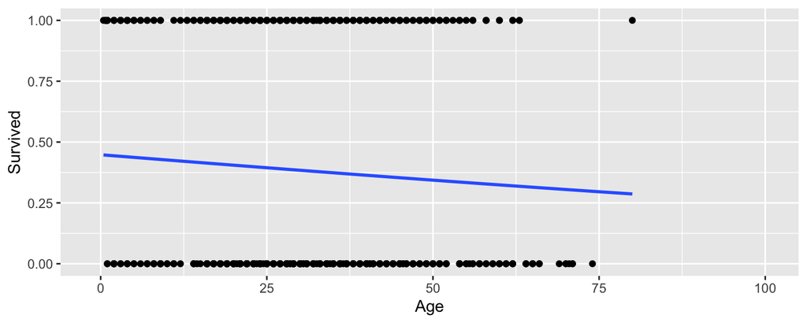

```r
titanic %>% ggplot(aes(x = Age, y = Survived)) + geom_point() +
  geom_smooth(method = "glm",
    method.args = list(family = "binomial"),
    se = FALSE) + xlim(-1, 100)
```

## Inspecting the data

```r
titanic %$% table(Pclass, Survived)
```

```
##       Survived
## Pclass   0   1
##      1  80 136
##      2  97  87
##      3 368 119
```

It seems that the higher the class (i.e. `1 > 2 > 3`), the higher the probability of survival.

We can verify this

```r
titanic %$% table(Pclass, Survived) %>% prop.table(margin = 1) %>% round(digits = 2)
```

```
##       Survived
## Pclass    0    1
##      1 0.37 0.63
##      2 0.53 0.47
##      3 0.76 0.24
```

## A more thorough inspection

## Fitting the titanic models

Let’s fit these models and gradually build them up in the number of predictors.

```r
fit1 <- titanic %$%
  glm(Survived ~ Age, family = binomial(link="logit"))

fit2 <- titanic %$%
  glm(Survived ~ Sex, family = binomial(link="logit"))

fit3 <- titanic %$%
  glm(Survived ~ Pclass, family = binomial(link="logit"))
```

## `Survived ~ Age`

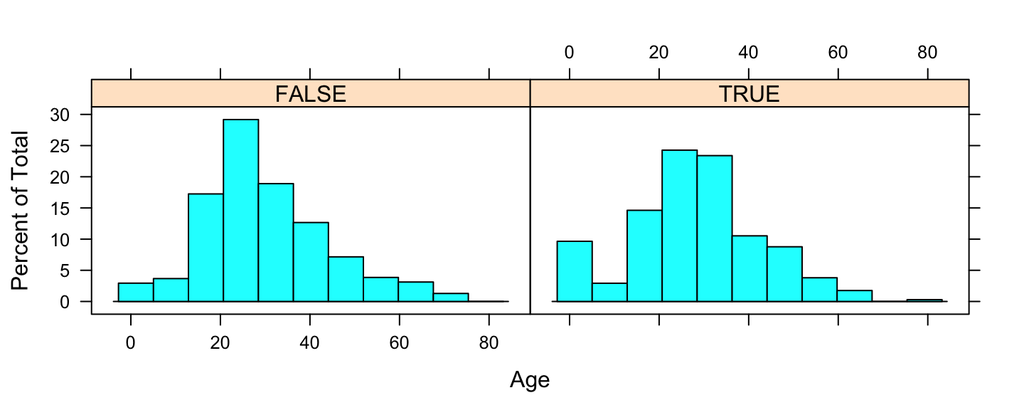

```r
titanic %$% histogram(~ Age | Survived == 1)
```

The distribution of `Age` for the survivors (`TRUE`) is different from the distribution of `Age` for the non-survivors (`FALSE`). Especially at the younger end there is a point mass for the survivors, which indicates that children have a higher probability of survival. However, it is not dramatically different.

## `Survived ~ Age`

```r
fit1 %>% summary %>% .$coefficients
```

```
##                 Estimate  Std. Error   z value   Pr(>|z|)
## (Intercept) -0.209188757 0.159493684 -1.311580 0.18966182
## Age         -0.008774355 0.004947362 -1.773542 0.07613892
```

We can see that there is a trend. The log odds of `Survived` decreases with increasing `Age`. For every year increase in age, the log-odds of `Survived` decreases with -0.0087744. However, this decrease is not too convincing given the effect, the standard error and the size of the data. Hence, the p-value is a little on the larger side.

When we inspect the deviance

```r
c(fit1$null.deviance, fit1$deviance)
```

```
## [1] 1182.770 1179.593
```

We see that there is almost no decrease in deviance between the empty model (i.e. the model with only an intercept) and the model with `Age` included. The difference in df is only 1 parameter.

## `Survived ~ Sex`

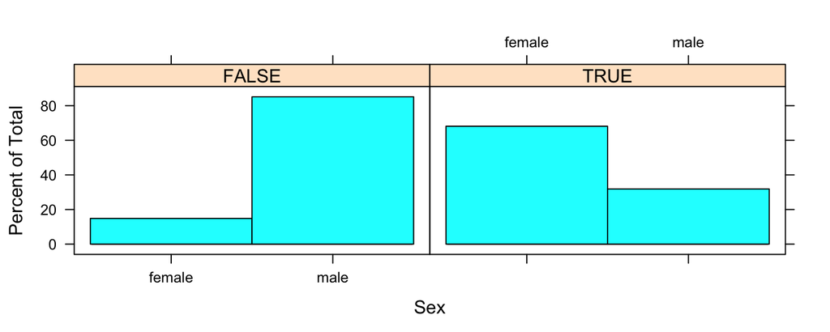

```r
titanic %$% histogram(~ Sex | Survived == 1)
```

Wow! These distributions are very different! Females seem to have a much higher probability of survival.

## `Survived ~ Sex`

```r
fit2 %>% summary %>% .$coefficients
```

```
##              Estimate Std. Error    z value     Pr(>|z|)
## (Intercept)  1.056589  0.1289864   8.191477 2.580394e-16
## Sexmale     -2.505126  0.1672333 -14.979827 9.947556e-51
```

The coefficients confirm this. The log odds of `Survived` decreases for males, when compared to females. The decrease is quite pronounced, too: -2.505126.

When we inspect the deviance

```r
c(fit2$null.deviance, fit2$deviance)
```

```
## [1] 1182.7699  916.1224
```

We see that there is a massive gain in the deviance between the empty model (i.e. the model with only an intercept) and the model with `Sex` included. The difference in df is only 1 parameter.

## `Survived ~ Pclass`

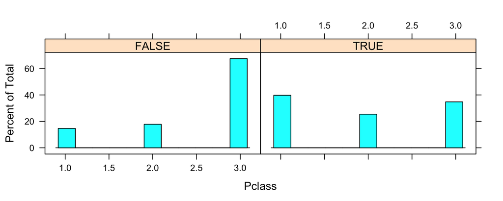

```r
titanic %$% histogram(~ Pclass | Survived == 1)
```

## `Survived ~ Pclass`

```r
fit3 %>% summary %>% .$coefficients
```

```
##               Estimate Std. Error   z value     Pr(>|z|)
## (Intercept)  1.4390660 0.20742485  6.937771 3.983356e-12
## Pclass      -0.8442286 0.08719006 -9.682624 3.574230e-22
```

Here, there is something wrong! Class is an ordered categorical variable, not a continuous variable. In other words, we cannot simply increase the log odds of `Survived` with -0.8442286 for every unit increase in `Pclass`.

### Why not?

If we would interpret these coefficients ‘as is’, we would assume that class two is twice the value for class 1, that class three is 1.5 times the value for class 2, and so on.

## Edit the data

```r
titanic %<>%
  mutate(Pclass = factor(Pclass, levels = c(3, 2, 1), ordered = FALSE))
str(titanic)
```

```
## 'data.frame':    887 obs. of  8 variables:
##  $ Survived               : int  0 1 1 1 0 0 0 0 1 1 ...
##  $ Pclass                 : Factor w/ 3 levels "3","2","1": 1 3 1 3 1 1 3 1 1 2 ...
##  $ Name                   : Factor w/ 887 levels "Capt. Edward Gifford Crosby",..: 602 823 172 814 733 464 700 33 842 839 ...
##  $ Sex                    : Factor w/ 2 levels "female","male": 2 1 1 1 2 2 2 2 1 1 ...
##  $ Age                    : num  22 38 26 35 35 27 54 2 27 14 ...
##  $ Siblings.Spouses.Aboard: int  1 1 0 1 0 0 0 3 0 1 ...
##  $ Parents.Children.Aboard: int  0 0 0 0 0 0 0 1 2 0 ...
##  $ Fare                   : num  7.25 71.28 7.92 53.1 8.05 ...
```

The `Pclass` column is now correctly coded as a factor. We ignore the ordering as this goes beyond the scope of the course.

## Titanic with main effects

```
##
## Call:
## glm(formula = Survived ~ Age + Sex + Pclass, family = binomial(link = "logit"))
##
## Deviance Residuals:
##     Min       1Q   Median       3Q      Max
## -2.6811  -0.6653  -0.4137   0.6367   2.4505
##
## Coefficients:
##             Estimate Std. Error z value Pr(>|z|)
## (Intercept)  1.17948    0.22784   5.177 2.26e-07 ***
## Age         -0.03427    0.00716  -4.787 1.69e-06 ***
## Sexmale     -2.58872    0.18701 -13.843  < 2e-16 ***
## Pclass2      1.25633    0.22646   5.548 2.90e-08 ***
## Pclass1      2.45544    0.25322   9.697  < 2e-16 ***
## ---
## Signif. codes:  0 '***' 0.001 '**' 0.01 '*' 0.05 '.' 0.1 ' ' 1
##
## (Dispersion parameter for binomial family taken to be 1)
##
##     Null deviance: 1182.77  on 886  degrees of freedom
## Residual deviance:  801.59  on 882  degrees of freedom
## AIC: 811.59
##
## Number of Fisher Scoring iterations: 5
```

## Titanic with interactions

```r
fit.interaction <- titanic %$% glm(Survived ~ Age * Sex * Pclass,
                                   family = binomial(link="logit"))
fit.interaction %>% summary %>% .$coefficients
```

```
##                        Estimate Std. Error    z value    Pr(>|z|)
## (Intercept)          0.38542858 0.35158572  1.0962578 0.272965982
## Age                 -0.01742787 0.01399943 -1.2448985 0.213169059
## Sexmale             -1.24102347 0.51966698 -2.3881130 0.016935134
## Pclass2              3.66379424 1.38138966  2.6522525 0.007995671
## Pclass1              1.11218683 1.49587117  0.7435044 0.457176346
## Age:Sexmale         -0.02261191 0.02066970 -1.0939639 0.273970802
## Age:Pclass2         -0.03196246 0.03845267 -0.8312158 0.405851754
## Age:Pclass1          0.08036169 0.05283156  1.5210925 0.128236622
## Sexmale:Pclass2     -1.91119761 1.57587112 -1.2127880 0.225210878
## Sexmale:Pclass1      0.81487712 1.66024791  0.4908165 0.623556217
## Age:Sexmale:Pclass2 -0.03128163 0.04938976 -0.6333627 0.526496788
## Age:Sexmale:Pclass1 -0.08001824 0.05687997 -1.4067912 0.159489308
```

## Interactions

An interaction occurs when the (causal) effect of one predictor on the outcome depends on the level of the (causal) effect of another predictor.

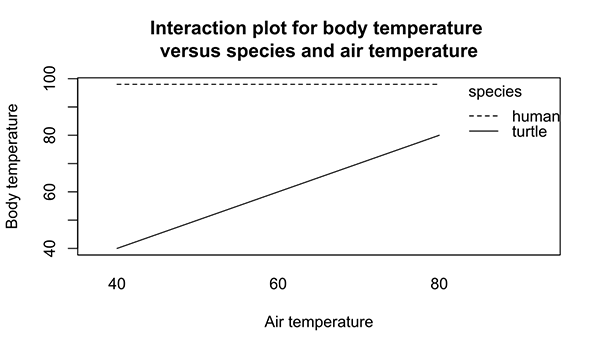

[Image Source](https://en.wikipedia.org/wiki/File:Interaction_plot_body_temp.svg)

E.g. the relation between body temperature and air temperature depends on the species.

## Visualizing the effects

To illustrate, I will limit this investigation to `Age` and `Pclass` for males only.

- We can use the `predict` function to illustrate the conditional probabilities within each class

To do so, we need to create a `new` data frame that has all the combinations of predictors we need.

```r
new <- data.frame(Pclass = factor(rep(c(1, 2, 3), c(80, 80, 80))),
                  Age = rep(1:80, times = 3),
                  Sex = rep("male", times = 240))
new <- cbind(new,
             predict(fit.interaction, newdata = new,
                     type = "link", se = TRUE))
head(new)
```

```
##   Pclass Age  Sex       fit    se.fit residual.scale
## 1      1   1 male 1.0317727 0.5963908              1
## 2      1   2 male 0.9920764 0.5826134              1
## 3      1   3 male 0.9523801 0.5688767              1
## 4      1   4 male 0.9126838 0.5551835              1
## 5      1   5 male 0.8729874 0.5415373              1
## 6      1   6 male 0.8332911 0.5279416              1
```

## Adding the predicted probabilities

There are two simple approaches to obtain the predicted probabilities. First, we could simply ask for the predicted response:

```r
new$prob <- predict(fit.interaction, newdata = new, type = "response")
```

Or we could use the distribution function `plogis()`:

```r
new$prob2 <- plogis(new$fit)
head(new)
```

```
##   Pclass Age  Sex       fit    se.fit residual.scale      prob     prob2
## 1      1   1 male 1.0317727 0.5963908              1 0.7372594 0.7372594
## 2      1   2 male 0.9920764 0.5826134              1 0.7294979 0.7294979
## 3      1   3 male 0.9523801 0.5688767              1 0.7215936 0.7215936
## 4      1   4 male 0.9126838 0.5551835              1 0.7135490 0.7135490
## 5      1   5 male 0.8729874 0.5415373              1 0.7053669 0.7053669
## 6      1   6 male 0.8332911 0.5279416              1 0.6970504 0.6970504
```

## Adding confidence intervals

```r
new %<>%
  mutate(lower = plogis(fit - 1.96 * se.fit),
         upper = plogis(fit + 1.96 * se.fit))

head(new)
```

```
##   Pclass Age  Sex       fit    se.fit residual.scale      prob     prob2
## 1      1   1 male 1.0317727 0.5963908              1 0.7372594 0.7372594
## 2      1   2 male 0.9920764 0.5826134              1 0.7294979 0.7294979
## 3      1   3 male 0.9523801 0.5688767              1 0.7215936 0.7215936
## 4      1   4 male 0.9126838 0.5551835              1 0.7135490 0.7135490
## 5      1   5 male 0.8729874 0.5415373              1 0.7053669 0.7053669
## 6      1   6 male 0.8332911 0.5279416              1 0.6970504 0.6970504
##       lower     upper
## 1 0.4657654 0.9003122
## 2 0.4626085 0.8941640
## 3 0.4594348 0.8876919
## 4 0.4562432 0.8808856
## 5 0.4530325 0.8737357
## 6 0.4498011 0.8662333
```

## What do we have?

A data frame with simulated `Pclass` and `Age` for males.

```r
new %>% summary()
```

```
##  Pclass      Age          Sex           fit              se.fit
##  1:80   Min.   : 1.00   male:240   Min.   :-7.3657   Min.   :0.1588
##  2:80   1st Qu.:20.75              1st Qu.:-3.2680   1st Qu.:0.2879
##  3:80   Median :40.50              Median :-1.7875   Median :0.4157
##         Mean   :40.50              Mean   :-2.0998   Mean   :0.5133
##         3rd Qu.:60.25              3rd Qu.:-0.7446   3rd Qu.:0.6093
##         Max.   :80.00              Max.   : 1.0318   Max.   :1.6068
##  residual.scale      prob               prob2
##  Min.   :1      Min.   :0.0006322   Min.   :0.0006322
##  1st Qu.:1      1st Qu.:0.0366906   1st Qu.:0.0366906
##  Median :1      Median :0.1433767   Median :0.1433767
##  Mean   :1      Mean   :0.2129610   Mean   :0.2129610
##  3rd Qu.:1      3rd Qu.:0.3220022   3rd Qu.:0.3220022
##  Max.   :1      Max.   :0.7372594   Max.   :0.7372594
##      lower               upper
##  Min.   :0.0000271   Min.   :0.01454
##  1st Qu.:0.0118488   1st Qu.:0.10794
##  Median :0.0826488   Median :0.25041
##  Mean   :0.1360227   Mean   :0.31211
##  3rd Qu.:0.2223781   3rd Qu.:0.44139
##  Max.   :0.4657654   Max.   :0.90031
```

## Visualizing the effects: link

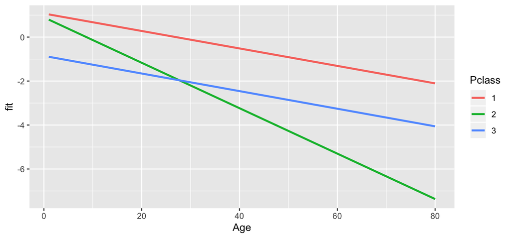

```r
new %>%
  ggplot(aes(x = Age, y = fit)) +
  geom_line(aes(colour = Pclass), lwd = 1)
```

## Visualizing the effects: probabilities

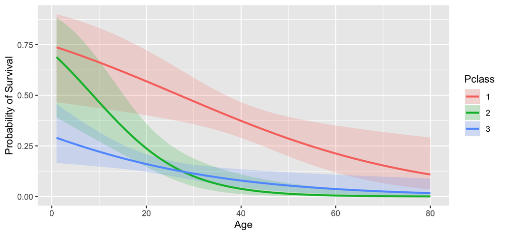

```r
new %>%
  ggplot(aes(x = Age, y = prob)) +
  geom_ribbon(aes(ymin = lower, ymax = upper, fill = Pclass), alpha = .2) +
  geom_line(aes(colour = Pclass), lwd = 1) + ylab("Probability of Survival")
```

## Model comparison

```r
fit <- titanic %$% glm(Survived ~ Age + Sex + Pclass, family = binomial(link="logit"))
anova(fit, fit.interaction, test = "Chisq")
```

```
## Analysis of Deviance Table
##
## Model 1: Survived ~ Age + Sex + Pclass
## Model 2: Survived ~ Age * Sex * Pclass
##   Resid. Df Resid. Dev Df Deviance  Pr(>Chi)
## 1       882     801.59
## 2       875     755.18  7   46.413 7.263e-08 ***
## ---
## Signif. codes:  0 '***' 0.001 '**' 0.01 '*' 0.05 '.' 0.1 ' ' 1
```

The interaction model fits much better to the data.

```r
AIC(fit, fit.interaction)
```

```
##                 df      AIC
## fit              5 811.5940
## fit.interaction 12 779.1805
```

## Prediction

```r
pred <- predict(fit, type = "response")
head(pred)
```

```
##          1          2          3          4          5          6
## 0.10309564 0.91153082 0.57158684 0.91947951 0.06856994 0.08829226
```

```r
pred <- ifelse(pred > 0.5, yes = 1, no = 0)
head(pred)
```

```
## 1 2 3 4 5 6
## 0 1 1 1 0 0
```

## Confusion matrix

```r
CM <- table(pred, titanic$Survived)
CM
```

```
##
## pred   0   1
##    0 463 100
##    1  82 242
```

The accuracy can then be calculated as the percentage of correct predictions, i.e. the sum over the diagonal elements divided by the total number of cases:

```r
correct <- CM %>% diag %>% sum
correct / sum(CM)
```

```
## [1] 0.794814
```

## In a function

```r
caret::confusionMatrix(as.factor(pred), reference = as.factor(titanic$Survived))
```

```
## Confusion Matrix and Statistics
##
##           Reference
## Prediction   0   1
##          0 463 100
##          1  82 242
##
##                Accuracy : 0.7948
##                  95% CI : (0.7667, 0.8209)
##     No Information Rate : 0.6144
##     P-Value [Acc > NIR] : <2e-16
##
##                   Kappa : 0.5627
##
##  Mcnemar's Test P-Value : 0.2076
##
##             Sensitivity : 0.8495
##             Specificity : 0.7076
##          Pos Pred Value : 0.8224
##          Neg Pred Value : 0.7469
##              Prevalence : 0.6144
##          Detection Rate : 0.5220
##    Detection Prevalence : 0.6347
##       Balanced Accuracy : 0.7786
##
##        'Positive' Class : 0
##
```

## Clustering

## Custom theme for plots

```r
helpIAmColourblind <- scale_color_manual(values = c("orange",
                                                    "blue",
                                                    "dark green"))
```

## Statistical learning

## Statistics is everywhere

Several questions involving statistics:

1. What is the relation between \(X\) and \(Y\)? (estimation)
2. What is the uncertainty around this effect? (estimation/inference)
3. What can I conclude about my population? (inference/hypothesis testing)
4. How can I best predict new observations? (prediction)
5. How can I show relevant patterns in my data? (dimension reduction / pattern recognition)

## Examples

- Radiologists use statistics to sharpen their images (e.g. MRI) and improve their diagnosis.
- Doctors use statistics to target your treatment to your symptoms or body.
- Physicists use statistics to find useful patterns in the huge data dumps by the Large Hadron Collider.
- Insurance companies use statistics to model risks for potential clients.
- Google uses statistics to serve you targeted ads.
- Netflix uses statistics to create hit shows.
- Spotify uses statistics to suggest music to you.

## Supervised learning

With *supervised learning* every observation on our predictor

\[x_i, i=1, \dots, n\]

has a corresponding outcome measurement

\[y_i\] such that

\[\hat{y_i}=f({\bf x_i})\quad \text{and} \quad y_i = f({\bf x_i})+\epsilon_i.\]

Examples:

- linear regression
- logistic regression
- k-nearest neighbours classifying

## Unsupervised learning

With *unsupervised learning* we have a vector of measurement \(\bf x_i\) for every unit \(i=1, \dots, n\), but we miss the associated response \(y_i\).

1. There is no outcome to predict
   - Hence you cannot fit e.g. a linear regression model
2. There is no outcome to verify the model
   - We lack the *truth* to supervise our analysis

## What can we do?

Find patterns in \(\bf x_1, \dots, x_n\)

We can use this model to e.g. find out if some cases are more similar than other cases or which variables explain most of the variation

Examples:

- Principal Components Analysis
- k-means clustering

## Two nonparametric algorithms

### K-nearest neighbours (KNN)

- supervised learning
- prediction
- classification

### K-means clustering (kmeans)

- unsupervised learning
- dimension reduction / pattern recognition
- clustering

## Example dataset

Let’s create some data from a multivariate normal distribution

We start with fixing the random seed

```r
set.seed(123)
```

and specifying the variance covariance matrix:

```r
sigma <- matrix(c(1, .5, .5, 1), 2, 2)
rownames(sigma) <- colnames(sigma) <- c("x1", "x2")
```

## Data relations

```r
sigma
```

```
##     x1  x2
## x1 1.0 0.5
## x2 0.5 1.0
```

Because the variances are `1`, the resulting data will have a correlation of \[\rho = \frac{\text{cov}(y, x)}{\sigma_y\sigma_x} = \frac{.5}{1\times1} = .5.\]

Let’s draw the data

```r
sim.data <- mvtnorm::rmvnorm(n     = 100,
                             mean  = c(5, 5),
                             sigma = sigma)
colnames(sim.data) <- c("x1", "x2")
```

## Plot the data

```r
sim.data %>%
  as_tibble %>%
  ggplot(aes(x1, x2)) +
  geom_point()
```

[figure not shown]

## Now add some clustering

```r
sim.data <-
  sim.data %>%
  as_tibble %>%
  mutate(class = sample(c("A", "B", "C"), size = 100, replace = TRUE))
```

We have added a new column that randomly assigns rows to level `A`, `B` or `C`

```r
sim.data %>% head
```

```
## # A tibble: 6 x 3
##      x1    x2 class
##   <dbl> <dbl> <chr>
## 1  4.40  4.63 C
## 2  6.52  5.47 C
## 3  5.57  6.69 C
## 4  5.12  3.90 A
## 5  4.22  4.39 A
## 6  6.28  5.66 C
```

## Plot the data again

```r
sim.data %>%
  ggplot(aes(x1, x2,  colour = class)) +
  geom_point() +
  helpIAmColourblind
```

[figure not shown]

## Adjust the clusters to make them distinct

```r
sim.data <-
  sim.data %>%
  mutate(x2 = case_when(class == "A" ~ x2 + 1.5,
                        class == "B" ~ x2 - 1.5,
                        class == "C" ~ x2 + 1.5),
         x1 = case_when(class == "A" ~ x1 - 1.5,
                        class == "B" ~ x1 - 0,
                        class == "C" ~ x1 + 1.5))
```

## The result: supervised

```r
sim.data %>%
  ggplot(aes(x1, x2,  colour = class)) +
  geom_point() +
  helpIAmColourblind
```

[figure not shown]

## The result: unsupervised

```r
sim.data %>%
  ggplot(aes(x1, x2)) +
  geom_point()
```

[figure not shown]

## K-Nearest Neighbors

## How does it work?

1. For every test observation \(x_0\) the \(K\) points that are close to \(x_0\) are identified.
2. These *closest* points form set \(\mathcal{N}_0\).
3. We estimate the probability for \(x_0\) being part of class \(j\) as the fraction of points in \(\mathcal{N}_0\) for whom the response equals \(j\): \[P(Y = j | X = x_0) = \frac{1}{K}\sum_{i\in\mathcal{N}_0}I(y_i=j)\]
4. The observation \(x_0\) is classified to the class with the largest probability

### In short

An observation gets that class assigned to which most of its \(K\) neighbours belong

## Why KNN?

Because \(X\) is assigned to the class to which most of the observations belong it is

- non-parametric
  - no assumptions about the distributions, or the shape of the decision boundary
- expected to be far better than logistic regression when decision boundaries are non-linear

However, we do not get parameters as with LDA and regression.

- We thus cannot determine the relative importance of predictors
- The “model” == the existing observations: instance-based learning

## Fitting a K-NN model

First we need to determine a training set

```r
set.seed(123)
sim.data <-
  sim.data %>%
  mutate(set = sample(c("Train", "Test"), size = 100,
                      prob = c(.25, .75), replace = TRUE))
sim.data
```

```
## # A tibble: 100 x 4
##       x1    x2 class set
##    <dbl> <dbl> <chr> <chr>
##  1  5.90  6.13 C     Test
##  2  8.02  6.97 C     Train
##  3  7.07  8.19 C     Test
##  4  3.62  5.40 A     Train
##  5  2.72  5.89 A     Train
##  6  7.78  7.16 C     Test
##  7  5.42  3.71 B     Test
##  8  6.43  8.08 C     Train
##  9  4.97  1.73 B     Test
## 10  4.06  6.22 A     Test
## # … with 90 more rows
```

## Fitting a K-NN model

Then we split the data into a training (build the model) and a test (verify the model) set

```r
train.data <- subset(sim.data, set == "Train", select = c(x1, x2))
test.data <-  subset(sim.data, set == "Test",  select = c(x1, x2))
obs.class <-  subset(sim.data, set == "Train", select = class)
```

Now we can fit the K-NN model

```r
fit.knn <- knn(train = train.data,
               test  = test.data,
               cl    = as.matrix(obs.class),
               k     = 3)
fit.knn
```

```
##  [1] C C C B B A B B A A C C A A C A A C C C B C C B B A B B B B A B A B A
## [36] C A C C B C C C A A C B C B A A B B C C A B B C C C B A B B C B A C A
## [71] C B A
## Levels: A B C
```

## Predictions

```r
class.test <- subset(sim.data, set == "Test", select = class) %>%
  as.matrix()
correct <- fit.knn == class.test
mean(correct)
```

```
## [1] 0.9589041
```

```r
table(fit.knn, class.test)
```

```
##        class.test
## fit.knn  A  B  C
##       A 21  0  0
##       B  0 24  1
##       C  0  2 25
```

## The (in)correct responses KNN = 3

```r
cbind(test.data, correct) %>%
  ggplot(aes(x1, x2,  colour = correct)) +
  geom_point() +
  scale_colour_manual(values = c("red", "black"))
```

[figure not shown]

## Fewer neighbours

```r
fit.knn <- knn(train = train.data,
               test  = test.data,
               cl    = as.matrix(obs.class),
               k     = 2)
correct <- fit.knn == class.test
mean(correct)
```

```
## [1] 0.9452055
```

```r
table(fit.knn, class.test)
```

```
##        class.test
## fit.knn  A  B  C
##       A 21  1  1
##       B  0 23  0
##       C  0  2 25
```

## More neighbours

```r
fit.knn <- knn(train = train.data,
               test  = test.data,
               cl    = as.matrix(obs.class),
               k     = 4)
correct <- fit.knn == class.test
mean(correct)
```

```
## [1] 0.9452055
```

```r
table(fit.knn, class.test)
```

```
##        class.test
## fit.knn  A  B  C
##       A 21  0  1
##       B  0 24  1
##       C  0  2 24
```

## Even more neighbours

```r
fit.knn <- knn(train = train.data,
               test = test.data,
               cl = as.matrix(obs.class),
               k = 10)
correct <- fit.knn == class.test
mean(correct)
```

```
## [1] 0.890411
```

```r
table(fit.knn, class.test)
```

```
##        class.test
## fit.knn  A  B  C
##       A 21  1  5
##       B  0 25  2
##       C  0  0 19
```

## The (in)correct responses KNN = 10

```r
cbind(test.data, correct) %>%
  ggplot(aes(x1, x2,  colour = correct)) +
  geom_point() +
  scale_colour_manual(values = c("red", "black"))
```

[figure not shown]

## Predicting a new observation

Let’s make a new observation:

```r
newObs <- data.frame(x1 = 5.5, x2 = 4.5)
```

[figure not shown]

## Predicting a new observation

[figure not shown]

## Predicting a new observation

Now we predict the class of this new observation, using the entire data for training our model

```r
knn(train = sim.data[, 1:2], cl = sim.data$class, k = 10, test = newObs)
```

```
## [1] B
## Levels: A B C
```

## K-means clustering

## Remember: unsupervised

```r
sim.data %>%
  ggplot(aes(x1, x2)) +
  geom_point()
```

[figure not shown]

## Goal: finding clusters in our data

K-means clustering partitions our dataset into \(K\) distinct, non-overlapping clusters or subgroups.

## What is a cluster?

A set of *relatively similar* observations.

### What is “relatively similar”?

This is up to the programmer/researcher to decide. For example, we can say the “within-class” variance is as small as possible and the between-class variance as large as possible.

## Why perform clustering?

We expect clusters in our data, but weren’t able to measure them

- potential new subtypes of cancer tissue

We want to summarise features into a categorical variable to use in further decisions/analysis

- subgrouping people by their spending types

## The k-means algorithm

1. Randomly assign values to K classes
2. Calculate the centroid (`colMeans`) for each class
3. Assign each value to its closest centroid class
4. If the assignments changed, go to step 2. else stop.

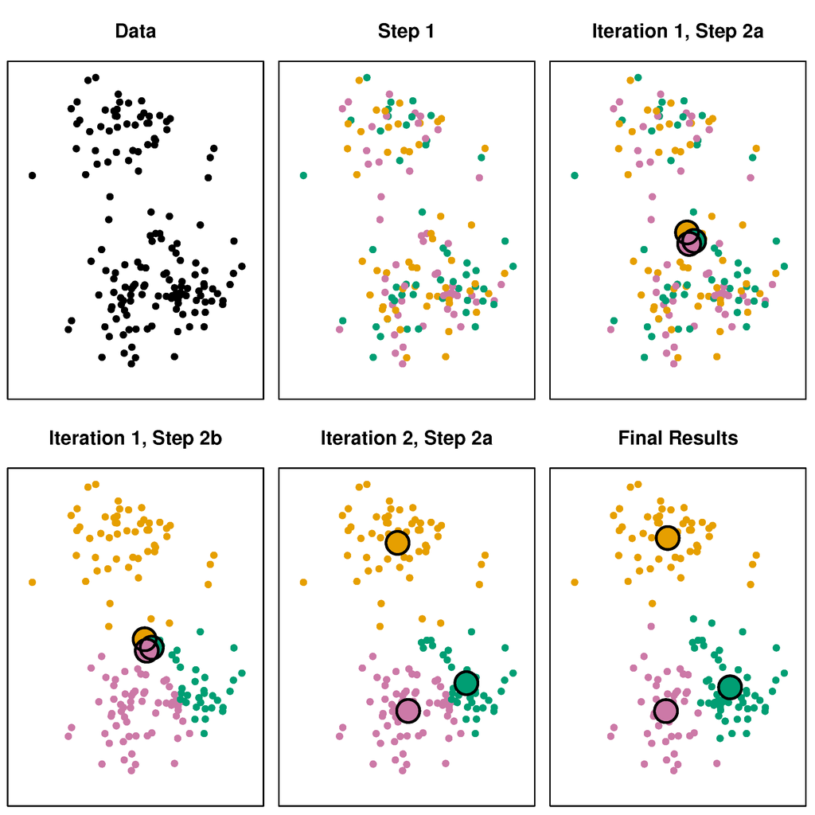

Source: James, G., Witten, D., Hastie, T., & Tibshirani, R. (2013). An introduction to statistical learning (Vol. 112). New York: Springer.

## The k-means algorithm

K is a **tuning parameter** (centers)

```r
(fitkm <- kmeans(sim.data[, 1:2], centers = 3))
```

```
## K-means clustering with 3 clusters of sizes 39, 35, 26
##
## Cluster means:
##         x1       x2
## 1 4.994727 3.532014
## 2 3.591445 6.394369
## 3 6.845077 6.976240
##
## Clustering vector:
##   [1] 3 3 3 2 2 3 1 3 1 2 1 1 1 2 2 2 3 3 2 2 3 2 3 1 2 2 3 1 2 1 2 1 3 1 3
##  [36] 1 2 1 2 1 1 1 1 2 1 2 1 2 3 1 2 3 1 1 1 3 2 2 1 1 2 2 3 1 3 1 1 1 2 1
##  [71] 2 2 2 1 1 3 3 2 1 1 3 3 3 3 1 2 2 1 2 1 1 3 1 2 3 2 2 3 1 2
##
## Within cluster sum of squares by cluster:
## [1] 49.33578 46.51667 49.21032
##  (between_SS / total_SS =  73.0 %)
##
## Available components:
##
## [1] "cluster"      "centers"      "totss"        "withinss"
## [5] "tot.withinss" "betweenss"    "size"         "iter"
## [9] "ifault"
```

## The result:

```r
sim.data$clust <- as.factor(fitkm$cluster)

sim.data %>% ggplot +
  geom_point(aes(x = x1, y = x2, colour = clust)) +
  helpIAmColourblind
```

[figure not shown]

## Comparison

```r
# this is the data-generating class

sim.data %>% ggplot +
  geom_point(aes(x = x1, y = x2, colour = class)) +
  helpIAmColourblind
```

[figure not shown]

## Centroids

```r
sim.data %>% ggplot +
  geom_point(aes(x = x1, y = x2, colour = clust)) +
  geom_point(aes(x = x1, y = x2), data = as.data.frame(fitkm$centers),
             size = 5, col = "red", alpha = 0.8) +
  helpIAmColourblind
```

[figure not shown]

## K = 5

[figure not shown]

## K = 2

[figure not shown]